# Minería de Reglas de Asociación

# Reglas de Asociación

## Asociaciones en la cesta de la compra (Market Basket Data)

Estudio de las transacciones contenida en `Groceries` con las funciones `summary` `itemInfo` `itemLabels` `itemFrequencyPlot`

```r
library(arules)
data("Groceries")

#solution
summary(Groceries)
```

```
transactions as itemMatrix in sparse format with
 9835 rows (elements/itemsets/transactions) and
 169 columns (items) and a density of 0.02609146

most frequent items:
      whole milk other vegetables       rolls/buns             soda           yogurt          (Other)
            2513             1903             1809             1715             1372            34055

element (itemset/transaction) length distribution:
sizes
   1    2    3    4    5    6    7    8    9   10   11   12   13   14   15   16   17   18   19   20   21   22   23   24   26   27   28
2159 1643 1299 1005  855  645  545  438  350  246  182  117   78   77   55   46   29   14   14    9   11    4    6    1    1    1    1
  29   32
   3    1

   Min. 1st Qu.  Median    Mean 3rd Qu.    Max.
  1.000   2.000   3.000   4.409   6.000  32.000

includes extended item information - examples:
```

|  | labels | level2 | level1 |
| --- | --- | --- | --- |
| 1 | frankfurter | sausage | meat and sausage |
| 2 | sausage | sausage | meat and sausage |
| 3 | liver loaf | sausage | meat and sausage |

```r
itemInfo(Groceries)
```

| labels | level2 | level1 |
| --- | --- | --- |
| frankfurter | sausage | meat and sausage |
| sausage | sausage | meat and sausage |
| liver loaf | sausage | meat and sausage |
| ham | sausage | meat and sausage |
| meat | sausage | meat and sausage |
| finished products | sausage | meat and sausage |
| organic sausage | sausage | meat and sausage |
| chicken | poultry | meat and sausage |
| turkey | poultry | meat and sausage |
| pork | pork | meat and sausage |

[output cut: 159 more lines]

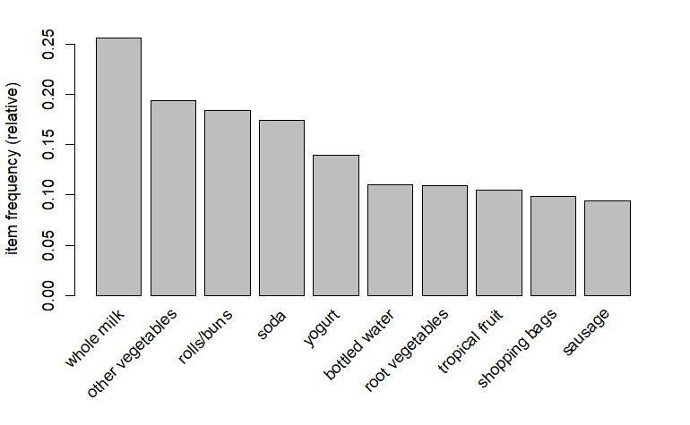

```r
itemFrequencyPlot(Groceries,topN=10)
```

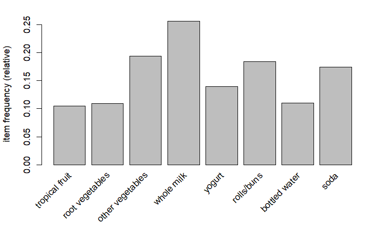

```r
itemFrequencyPlot(Groceries,support=0.1)
```

Combinaciones de pares de *items* `crossTable`.

```r
table.trans <- crossTable(Groceries,sort=T)
table.trans[1:5,1:5]
```

```
                 whole milk other vegetables rolls/buns soda yogurt
whole milk             2513              736        557  394    551
other vegetables        736             1903        419  322    427
rolls/buns              557              419       1809  377    338
soda                    394              322        377 1715    269
yogurt                  551              427        338  269   1372
```

`priori(data, parameter = NULL, appearance = NULL, control = NULL,…)`

```r
rules <- apriori(Groceries,parameter = c(support=0.01,confidence=0.5),control=list(verbose=T))
```

```
Apriori

Parameter specification:
```

|  | confidence | minval | smax | arem | aval | originalSupport | maxtime | support | minlen | maxlen | target | ext |
| --- | --- | --- | --- | --- | --- | --- | --- | --- | --- | --- | --- | --- |
|  | 0.5 | 0.1 | 1 | none | FALSE | TRUE | 5 | 0.01 | 1 | 10 | rules | TRUE |

```
Algorithmic control:
```

|  | filter | tree | heap | memopt | load | sort | verbose |
| --- | --- | --- | --- | --- | --- | --- | --- |
|  | 0.1 | TRUE | TRUE | FALSE | TRUE | 2 | TRUE |

```
Absolute minimum support count: 98

set item appearances ...[0 item(s)] done [0.00s].
set transactions ...[169 item(s), 9835 transaction(s)] done [0.00s].
sorting and recoding items ... [88 item(s)] done [0.00s].
creating transaction tree ... done [0.00s].
checking subsets of size 1 2 3 4 done [0.00s].
writing ... [15 rule(s)] done [0.00s].
creating S4 object  ... done [0.00s].
```

```r
summary(rules)
```

```
set of 15 rules

rule length distribution (lhs + rhs):sizes
 3
15

   Min. 1st Qu.  Median    Mean 3rd Qu.    Max.
      3       3       3       3       3       3

summary of quality measures:
    support          confidence        coverage            lift           count
 Min.   :0.01007   Min.   :0.5000   Min.   :0.01729   Min.   :1.984   Min.   : 99.0
 1st Qu.:0.01174   1st Qu.:0.5151   1st Qu.:0.02089   1st Qu.:2.036   1st Qu.:115.5
 Median :0.01230   Median :0.5245   Median :0.02430   Median :2.203   Median :121.0
 Mean   :0.01316   Mean   :0.5411   Mean   :0.02454   Mean   :2.299   Mean   :129.4
 3rd Qu.:0.01403   3rd Qu.:0.5718   3rd Qu.:0.02598   3rd Qu.:2.432   3rd Qu.:138.0
 Max.   :0.02227   Max.   :0.5862   Max.   :0.04342   Max.   :3.030   Max.   :219.0

mining info:
```

|  | data | ntransactions | support | confidence | call |
| --- | --- | --- | --- | --- | --- |
|  | Groceries | 9835 | 0.01 | 0.5 | apriori(data = Groceries, parameter = c(support = 0.01, confidence = 0.5), control = list(verbose = T)) |

```r
inspect(rules)
```

|  | lhs |  | rhs | support | confidence | coverage | lift | count |
| --- | --- | --- | --- | --- | --- | --- | --- | --- |
| [1] | {curd, yogurt} | => | {whole milk} | 0.01006609 | 0.5823529 | 0.01728521 | 2.279125 | 99 |
| [2] | {other vegetables, butter} | => | {whole milk} | 0.01148958 | 0.5736041 | 0.02003050 | 2.244885 | 113 |
| [3] | {other vegetables, domestic eggs} | => | {whole milk} | 0.01230300 | 0.5525114 | 0.02226741 | 2.162336 | 121 |
| [4] | {yogurt, whipped/sour cream} | => | {whole milk} | 0.01087951 | 0.5245098 | 0.02074225 | 2.052747 | 107 |
| [5] | {other vegetables, whipped/sour cream} | => | {whole milk} | 0.01464159 | 0.5070423 | 0.02887646 | 1.984385 | 144 |
| [6] | {pip fruit, other vegetables} | => | {whole milk} | 0.01352313 | 0.5175097 | 0.02613116 | 2.025351 | 133 |
| [7] | {citrus fruit, root vegetables} | => | {other vegetables} | 0.01037112 | 0.5862069 | 0.01769192 | 3.029608 | 102 |
| [8] | {tropical fruit, root vegetables} | => | {other vegetables} | 0.01230300 | 0.5845411 | 0.02104728 | 3.020999 | 121 |
| [9] | {tropical fruit, root vegetables} | => | {whole milk} | 0.01199797 | 0.5700483 | 0.02104728 | 2.230969 | 118 |
| [10] | {tropical fruit, yogurt} | => | {whole milk} | 0.01514997 | 0.5173611 | 0.02928317 | 2.024770 | 149 |

[output cut: 5 more lines]

Estudio de las reglas de asociación con:

Conjuntos de *items* `inspect(items(rules))`

Reglas `inspect(rules)` , `inspect(lhs(rules))`

Calidad de las reglas `quality(rules)`

Reglas que cumplen características `inspect(head(sort(rules, by = "confidence"),n=10))`

```r
inspect(head(sort(rules, by = "confidence"),n=10))
```

|  | lhs |  | rhs | support | confidence | coverage | lift | count |
| --- | --- | --- | --- | --- | --- | --- | --- | --- |
| [1] | {citrus fruit, root vegetables} | => | {other vegetables} | 0.01037112 | 0.5862069 | 0.01769192 | 3.029608 | 102 |
| [2] | {tropical fruit, root vegetables} | => | {other vegetables} | 0.01230300 | 0.5845411 | 0.02104728 | 3.020999 | 121 |
| [3] | {curd, yogurt} | => | {whole milk} | 0.01006609 | 0.5823529 | 0.01728521 | 2.279125 | 99 |
| [4] | {other vegetables, butter} | => | {whole milk} | 0.01148958 | 0.5736041 | 0.02003050 | 2.244885 | 113 |
| [5] | {tropical fruit, root vegetables} | => | {whole milk} | 0.01199797 | 0.5700483 | 0.02104728 | 2.230969 | 118 |
| [6] | {root vegetables, yogurt} | => | {whole milk} | 0.01453991 | 0.5629921 | 0.02582613 | 2.203354 | 143 |
| [7] | {other vegetables, domestic eggs} | => | {whole milk} | 0.01230300 | 0.5525114 | 0.02226741 | 2.162336 | 121 |
| [8] | {yogurt, whipped/sour cream} | => | {whole milk} | 0.01087951 | 0.5245098 | 0.02074225 | 2.052747 | 107 |
| [9] | {root vegetables, rolls/buns} | => | {whole milk} | 0.01270971 | 0.5230126 | 0.02430097 | 2.046888 | 125 |
| [10] | {pip fruit, other vegetables} | => | {whole milk} | 0.01352313 | 0.5175097 | 0.02613116 | 2.025351 | 133 |

Ordenar las reglas `sort(rules, by=…)` . Muestra las 5 primeras reglas ordenadas por `lift`.

|  | lhs |  | rhs | support | confidence | coverage | lift | count |
| --- | --- | --- | --- | --- | --- | --- | --- | --- |
| [1] | {citrus fruit, root vegetables} | => | {other vegetables} | 0.01037112 | 0.5862069 | 0.01769192 | 3.029608 | 102 |
| [2] | {tropical fruit, root vegetables} | => | {other vegetables} | 0.01230300 | 0.5845411 | 0.02104728 | 3.020999 | 121 |
| [3] | {root vegetables, rolls/buns} | => | {other vegetables} | 0.01220132 | 0.5020921 | 0.02430097 | 2.594890 | 120 |
| [4] | {root vegetables, yogurt} | => | {other vegetables} | 0.01291307 | 0.5000000 | 0.02582613 | 2.584078 | 127 |
| [5] | {curd, yogurt} | => | {whole milk} | 0.01006609 | 0.5823529 | 0.01728521 | 2.279125 | 99 |

Buscar reglas y/o filtrar `subset(rules, <<condición lógica>>)`. Obtén las reglas de asociación que tengan como consecuencia alguna concreta.

- x %in% table
- x %pin% table <-> partial “milk”
- x %ain% table <->all “citrus fruit”
- x %oin% table <->only “other vegetables”

```r
rules_selected <- arules::subset(rules,subset=rhs %pin% 'milk')
inspect(rules_selected)
```

|  | lhs |  | rhs | support | confidence | coverage | lift | count |
| --- | --- | --- | --- | --- | --- | --- | --- | --- |
| [1] | {curd, yogurt} | => | {whole milk} | 0.01006609 | 0.5823529 | 0.01728521 | 2.279125 | 99 |
| [2] | {other vegetables, butter} | => | {whole milk} | 0.01148958 | 0.5736041 | 0.02003050 | 2.244885 | 113 |
| [3] | {other vegetables, domestic eggs} | => | {whole milk} | 0.01230300 | 0.5525114 | 0.02226741 | 2.162336 | 121 |
| [4] | {yogurt, whipped/sour cream} | => | {whole milk} | 0.01087951 | 0.5245098 | 0.02074225 | 2.052747 | 107 |
| [5] | {other vegetables, whipped/sour cream} | => | {whole milk} | 0.01464159 | 0.5070423 | 0.02887646 | 1.984385 | 144 |
| [6] | {pip fruit, other vegetables} | => | {whole milk} | 0.01352313 | 0.5175097 | 0.02613116 | 2.025351 | 133 |
| [7] | {tropical fruit, root vegetables} | => | {whole milk} | 0.01199797 | 0.5700483 | 0.02104728 | 2.230969 | 118 |
| [8] | {tropical fruit, yogurt} | => | {whole milk} | 0.01514997 | 0.5173611 | 0.02928317 | 2.024770 | 149 |
| [9] | {root vegetables, yogurt} | => | {whole milk} | 0.01453991 | 0.5629921 | 0.02582613 | 2.203354 | 143 |
| [10] | {root vegetables, rolls/buns} | => | {whole milk} | 0.01270971 | 0.5230126 | 0.02430097 | 2.046888 | 125 |

[output cut: 1 more lines]

Almacenar las reglas en data.frame con `as(rules,"data.frame")`

|  | rules | support | confidence | coverage | lift | count |
| --- | --- | --- | --- | --- | --- | --- |
| 1 | {curd,yogurt} => {whole milk} | 0.01006609 | 0.5823529 | 0.01728521 | 2.279125 | 99 |
| 2 | {other vegetables,butter} => {whole milk} | 0.01148958 | 0.5736041 | 0.02003050 | 2.244885 | 113 |
| 3 | {other vegetables,domestic eggs} => {whole milk} | 0.01230300 | 0.5525114 | 0.02226741 | 2.162336 | 121 |
| 4 | {yogurt,whipped/sour cream} => {whole milk} | 0.01087951 | 0.5245098 | 0.02074225 | 2.052747 | 107 |
| 5 | {other vegetables,whipped/sour cream} => {whole milk} | 0.01464159 | 0.5070423 | 0.02887646 | 1.984385 | 144 |
| 6 | {pip fruit,other vegetables} => {whole milk} | 0.01352313 | 0.5175097 | 0.02613116 | 2.025351 | 133 |
| 7 | {citrus fruit,root vegetables} => {other vegetables} | 0.01037112 | 0.5862069 | 0.01769192 | 3.029608 | 102 |
| 8 | {tropical fruit,root vegetables} => {other vegetables} | 0.01230300 | 0.5845411 | 0.02104728 | 3.020999 | 121 |
| 9 | {tropical fruit,root vegetables} => {whole milk} | 0.01199797 | 0.5700483 | 0.02104728 | 2.230969 | 118 |
| 10 | {tropical fruit,yogurt} => {whole milk} | 0.01514997 | 0.5173611 | 0.02928317 | 2.024770 | 149 |

[output cut: 5 more lines]

Representa las reglas `?plot.rules` del paquete `arulesViz`

```r
if (!require("BiocManager", quietly = TRUE))
    install.packages("BiocManager")
BiocManager::install("Rgraphviz")
a
```

```r
library(arulesViz)
library(Rgraphviz)
#plot(rules,engine="htmlwidget")
#plot(rules,engine='htmlwidget',method="grouped",k=15)
plot(rules,method='graph',engine='htmlwidget')
```

[interactive chart not shown]

Buscar reglas concretas especificando `appareance=list(rhs=…, lhs=…, items=….)`

```r
#parameter = list(minlen=2, supp=0.005, conf=0.5),
#appearance = list(rhs=c("other vegetables"),default="lhs"),

rules <- apriori(Groceries,parameter=c(minlen=2,maxlen=5,support=0.01,confidence=0.5),appearance = list(rhs=c("other vegetables"),default="lhs"),control = list(verbose=F))
```

# Reglas de Asociación Last.fm

```r
library(dplyr)
fname       <- "http://www.biz.uiowa.edu/faculty/jledolter/DataMining/lastfm.csv"
lastfm      <- read.csv(fname, stringsAsFactors=FALSE)
summary(lastfm)
```

```
      user          artist              sex              country
 Min.   :    1   Length:289955      Length:289955      Length:289955
 1st Qu.: 4935   Class :character   Class :character   Class :character
 Median : 9838   Mode  :character   Mode  :character   Mode  :character
 Mean   : 9852
 3rd Qu.:14769
 Max.   :19718
```

```r
dsname      <- "lastfm"
ds          <- get(dsname) %>% tbl_df()
ds
```

| user | artist | sex | country |
| --- | --- | --- | --- |
| 1 | red hot chili peppers | f | Germany |
| 1 | the black dahlia murder | f | Germany |
| 1 | goldfrapp | f | Germany |
| 1 | dropkick murphys | f | Germany |
| 1 | le tigre | f | Germany |
| 1 | schandmaul | f | Germany |
| 1 | edguy | f | Germany |
| 1 | jack johnson | f | Germany |
| 1 | eluveitie | f | Germany |
| 1 | the killers | f | Germany |

[output cut: 990 more lines]

```r
ds <- ds %>% select(user, artist) %>% unique()
dataset.lastfm<-as.data.frame(ds)
save(dataset.lastfm, file="lastfm.RData")
```

Utilizando la función `split` y `as(, "transactions")` crea las transacciones para buscar reglas de asociación de artistas musicales de last.fm.

`Transactions can be created by coercion from lists containing transactions, but also from matrix and data.frames.`

```r
split(dataset.lastfm$artist,dataset.lastfm$user)
```

[output not shown]

[output cut: 3929 more lines]

```
$`790`
 [1] "new order"                  "pet shop boys"              "parov stelar"               "the smashing pumpkins"
 [5] "the cure"                   "interpol"                   "oasis"                      "aphex twin"
 [9] "röyksopp"                   "air"                        "my bloody valentine"        "massive attack"
[13] "kings of convenience"       "the future sound of london" "booka shade"                "primal scream"
[17] "kanye west"                 "joy division"               "the stone roses"            "burial"
[21] "nightmares on wax"          "faithless"                  "daft punk"                  "hercules and love affair"
[25] "cansei de ser sexy"         "madonna"                    "trentemøller"               "u2"
[29] "morcheeba"                  "dido"                       "amy winehouse"              "the cranberries"
[33] "santogold"                  "corinne bailey rae"         "keane"                      "sade"

$`791`
 [1] "gogol bordello"          "elliott smith"           "wu-tang clan"            "bob dylan"               "of montreal"
 [6] "dropkick murphys"        "modest mouse"            "animal collective"       "blonde redhead"          "iron & wine"
[11] "at the gates"            "dead kennedys"           "iron maiden"             "arch enemy"              "the beatles"
```

Analizamos qué `items` son más frecuentes con `itemFrequencyPlot(trans, topN=NULL)`

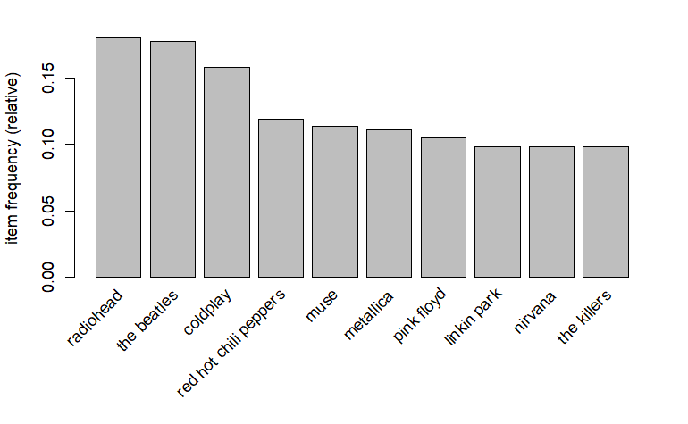

Construimos el modelo mediante `apriori`. Encontramos las reglas de `support=0.01` y `confidence=0.5`

```r
rules <- apriori(trans.bien,parameter=c(support=0.01,confidence=0.5),control = list(verbose=F))
```

Inspeccionamos LHS y RHS de las reglas

|  | lhs |  | rhs | support | confidence | coverage | lift | count |
| --- | --- | --- | --- | --- | --- | --- | --- | --- |
| [1] | {t.i.} | => | {kanye west} | 0.01040000 | 0.5672727 | 0.01833333 | 8.854413 | 156 |
| [2] | {the pussycat dolls} | => | {rihanna} | 0.01040000 | 0.5777778 | 0.01800000 | 13.415893 | 156 |
| [3] | {the fray} | => | {coldplay} | 0.01126667 | 0.5168196 | 0.02180000 | 3.260006 | 169 |
| [4] | {sonata arctica} | => | {nightwish} | 0.01346667 | 0.5101010 | 0.02640000 | 8.236292 | 202 |
| [5] | {judas priest} | => | {iron maiden} | 0.01353333 | 0.5075000 | 0.02666667 | 8.562992 | 203 |
| [6] | {the kinks} | => | {the beatles} | 0.01360000 | 0.5298701 | 0.02566667 | 2.979030 | 204 |
| [7] | {travis} | => | {coldplay} | 0.01373333 | 0.5628415 | 0.02440000 | 3.550304 | 206 |
| [8] | {the flaming lips} | => | {radiohead} | 0.01306667 | 0.5297297 | 0.02466667 | 2.938589 | 196 |
| [9] | {megadeth} | => | {metallica} | 0.01626667 | 0.5281385 | 0.03080000 | 4.743759 | 244 |
| [10] | {simon & garfunkel} | => | {the beatles} | 0.01540000 | 0.5238095 | 0.02940000 | 2.944956 | 231 |

[output cut: 40 more lines]

Inspeccionamos la calidad de las reglas

|  | support | confidence | coverage | lift | count |
| --- | --- | --- | --- | --- | --- |
| 1 | 0.01040000 | 0.5672727 | 0.01833333 | 8.854413 | 156 |
| 2 | 0.01040000 | 0.5777778 | 0.01800000 | 13.415893 | 156 |
| 3 | 0.01126667 | 0.5168196 | 0.02180000 | 3.260006 | 169 |
| 4 | 0.01346667 | 0.5101010 | 0.02640000 | 8.236292 | 202 |
| 5 | 0.01353333 | 0.5075000 | 0.02666667 | 8.562992 | 203 |
| 6 | 0.01360000 | 0.5298701 | 0.02566667 | 2.979030 | 204 |
| 7 | 0.01373333 | 0.5628415 | 0.02440000 | 3.550304 | 206 |
| 8 | 0.01306667 | 0.5297297 | 0.02466667 | 2.938589 | 196 |
| 9 | 0.01626667 | 0.5281385 | 0.03080000 | 4.743759 | 244 |
| 10 | 0.01540000 | 0.5238095 | 0.02940000 | 2.944956 | 231 |

[output cut: 40 more lines]

[output not shown]

[output cut: 40 more lines]

Representamos la calidad de las reglas con `plot` …

[interactive chart not shown]